# How to create a shapefile with beg/end Log mile for a interstate?

# Foundamental files

- roadway shapefile i.e., Statewide_Road_geometrics_data.shp, contains route number, name.
- county shapefile, i.e., TN_count.shp, used for cut routes into multiple parts.

## Step 1 Prepare Interstate segments (Note: multple polylines)

- Select segments of a interstate from a roadway shapefile (e.g., DOT roadway shapefile).
- Save selected segments of a specific interstate, name it as "step1RouteSelection.shp"
- example:
1. select target corridor \

[figure not shown]

2. right-click the layer "Statewide_Roadway_Geometry" and go to selection, and create layer from selected layers (I_24_segments).
3. Let's save this layer (export->data) to folder "I_24_raw"

## Step 2 Dissolve segments

- **Dissolve** selected segments using shape file "step1RouteSelection.shp"
- Save dissolved layer as "step2RouteDissolve.shp"
- The purpose of dissolving segments is to unite all segments into a single route (a polyline)
- Example \

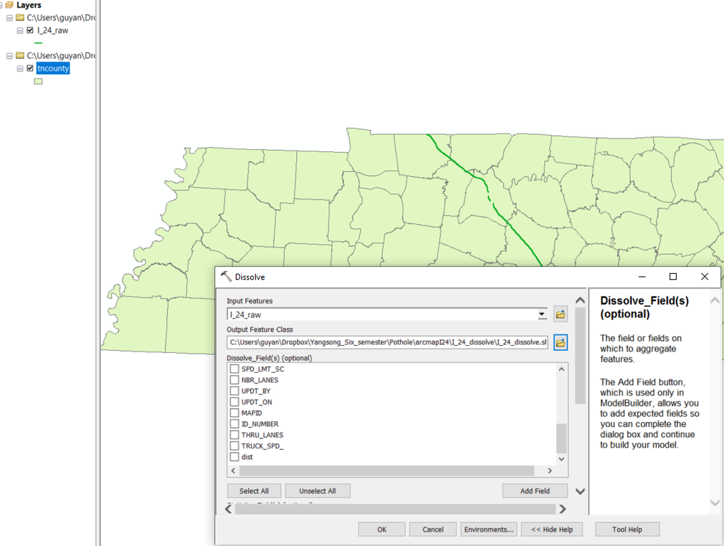

- Save new layer as "I_24_dissolve" and export the layer to folder "I_24_dissolve"

## Step 3 Cut route by county

- Intersect route (polyline) with county (polygon)
- Select line as output
- Example, input file "I_24_dissolve" and "tncounty"

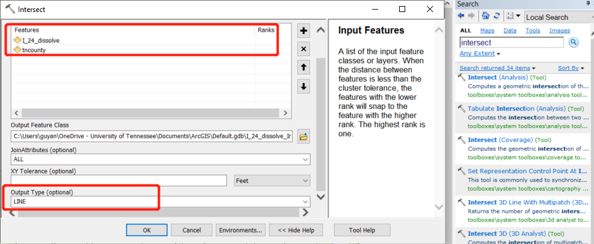

- Save the new layer as "I_24_cut_by_county" and save it to folder "I_24_cut_by_county"

Step 4 Check the corridor within county

- This step is to make sure the corridor length is close to (or equal to) the length of report. To do this, we can compare the end of log mile
- Before we check the route length, let's see if we have following layers.

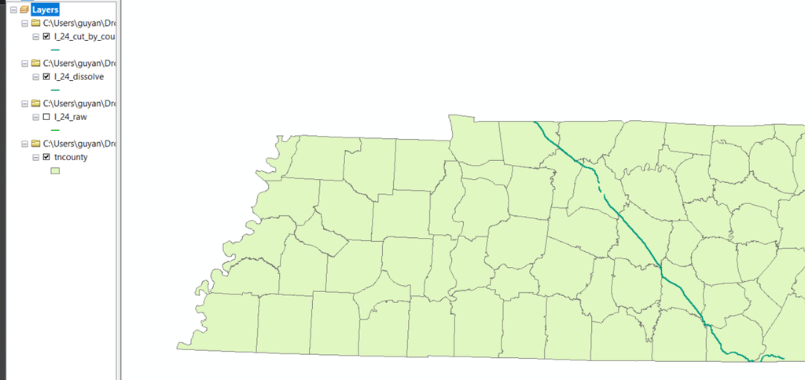

- Then, add a new field for layer "I_24_cut_by_county" for the convenience of checking the corridor length

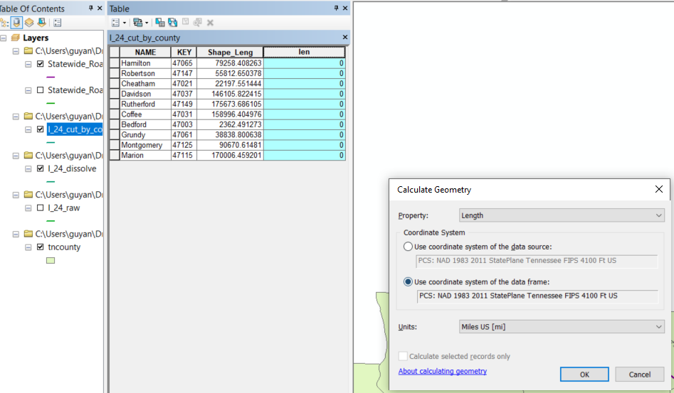

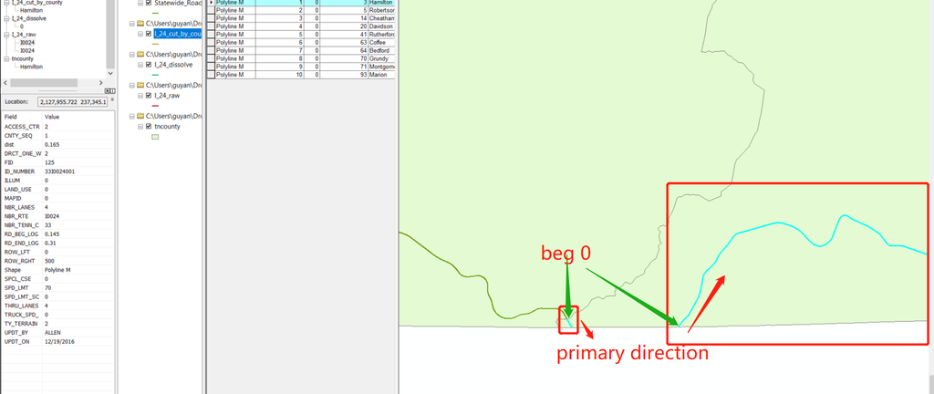

Specifically, we need to right-click the blank area of the arcmap GUI. Go to check on Advanced Editing. Then go to editor menor, select polyline and start editing. The key functionalitys are shown in below figure.

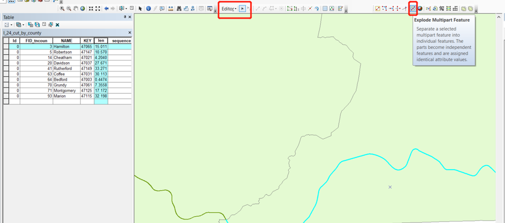

Add new column "sequence", Meanwhile, update the length "len" if needed.

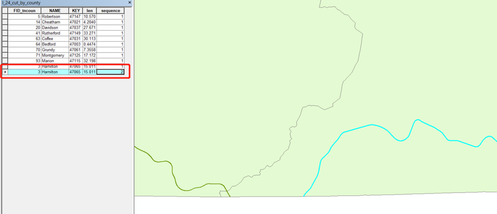

After check, we should have following information, especially added len. sequence, Cty_code

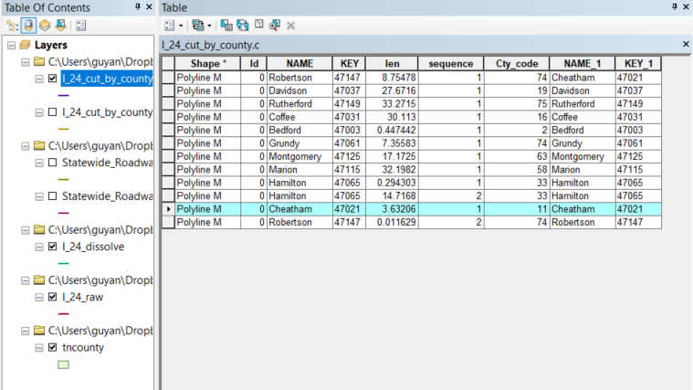

## Generate points along lines (e.g., every 0.1 miles)

- Examples

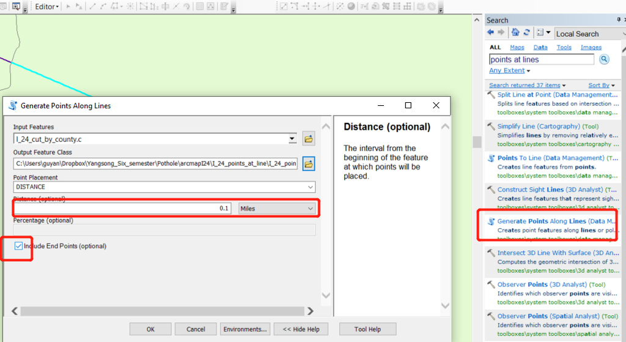

Save the new layer as "I_24_points_at_line" and save it to folder 'I_24_points_at_line'

## Important step

Now we are stepping into a very important step. That is, we want to split lines at points while preserving the order of segments.Here's the solution i found in web [split_line_at_points](https://stackoverflow.com/questions/26473572/when-using-split-lines-at-points-in-arcmap-preserve-sequential-order-of-resulti)

1. dissolve the segments ("I_24_cut_by_county") to single feature (called it "I_24_dissolve_back"), This ensures that the parent line actually has a vertex at each point.
2. Split Lines ("I_24_dissolve_back") at Vertices on feature_diss; output is "I_24_segments_at_vertices"
3. In the I_24_segments_at_vertices's attribute table, create a new field to store a copy of the FID. Calculate it as such
4. Split Lines ("I_24_cut_by_county") at points ("I_24_points_at_line"), note that, Search Radius should be the segement length such as 0.1 mile. The output layer is "I_24_segments_at_points"
5. Spatial Join "I_24_segments_at_vertices" to "I_24_segments_at_points", *average* the fields from "I_24_segments_at_vertices" in the output table. Label the output layer as "I_24_seg_spatial_join" *this step is also for ordering the segments by id of I_24_segments_at_vertices* After this step, we can delete some useless/duplicate columns (fields) to make the table more brief. Importantly, the semgent sequence can be determined by the *Avg_copy_id*, which will be further used to add the beg/end logmiles for segments.
6. A little tip here, we can recalculate the length and check if they (marjority of them) are equal to 0.1

Retrieve segments.\

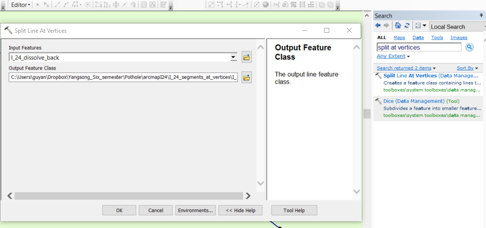

Copy Id. \

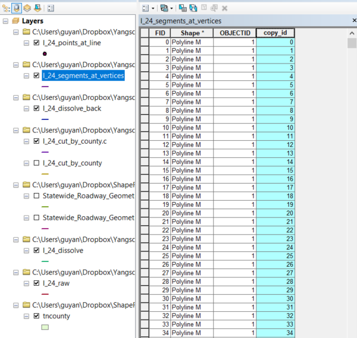

Split lines at points\

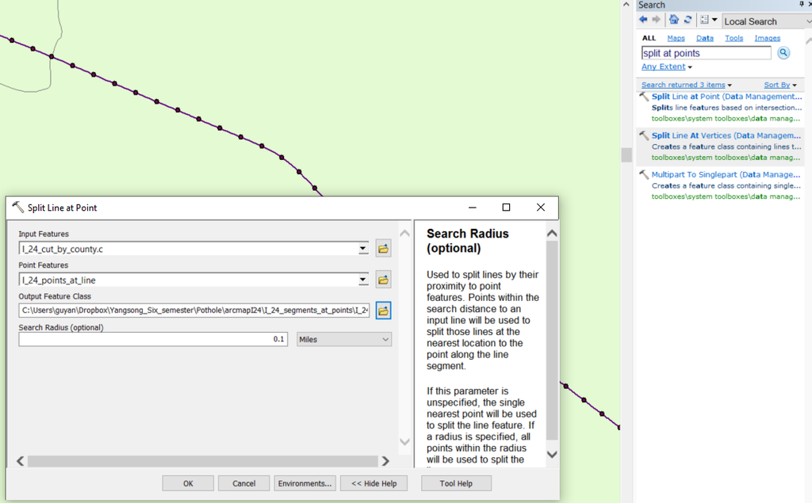

Order segments\

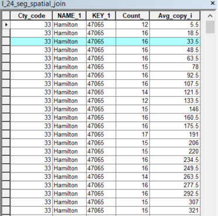

The final table should contain below information for further calculation

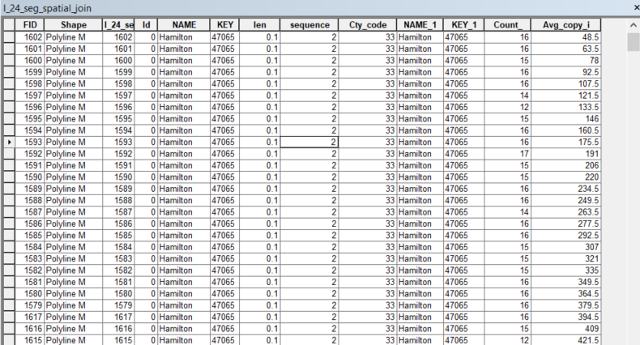

## Add beg/end log miles to segments.

It is not easy to add beg/end log miles in the Arcmap table becasue we need to loop all sections in crossed counties. The best way I thought is to export the dataframe to excel (or dbf file), and use python to do it. Anyway, it might be possible of using arcpy package.

# Apply python function to add log miles

- refer to notebook "PotholeMatch.a.ipynb"

```python
%load_ext autoreload
%autoreload 2
```

```python
import sys
# # sys.path.append(r'')
sys.path.insert(0, r'C:\Users\guyan\Dropbox\Yangsong_Six_semester\Pothole\scripts')
from utli import *
import geopandas as gpd
```

```python
import os
root_pth = r'C:\Users\guyan\Dropbox\Yangsong_Six_semester\Pothole\GalleryofMatched'
```

# Primary direction

```python
routeNum = 24
direction = 'P'
# pth_ordered = r'C:\Users\guyan\Dropbox\Yangsong_Six_semester\Pothole\arcmap\I_40_seg_points_all\I_40_ordered.xlsx'
# pth_shp = r'C:\Users\guyan\Dropbox\Yangsong_Six_semester\Pothole\arcmap\I_40_seg_points_all\I_40_logmiles.xlsx'
pth_ordered = r'C:\Users\guyan\Dropbox\Yangsong_Six_semester\Pothole\arcmapI24\excels\I_24_segments.xlsx'
# pth_shp = r'None'
pth_tar = r'C:\Users\guyan\Dropbox\Yangsong_Six_semester\Pothole\scripts\2021_distress.xlsx'

I_24 = logTarget(routeNum, direction,pth_ordered, pth_tar)
```

```python
df_add_mile = I_24.addLogMiles(by_col = 'Avg_copy_i',savefile = os.path.join(root_pth, 'I_{}_logmiles_{}.csv'.format(routeNum, direction)))
```

```
County Robertson
 count of segments is less then 0.1 mile which would be the end of corridor in one county
 5
County Davidson
 count of segments is less then 0.1 mile which would be the end of corridor in one county
 5
County Rutherford
 count of segments is less then 0.1 mile which would be the end of corridor in one county
 1
County Coffee
 count of segments is less then 0.1 mile which would be the end of corridor in one county
 1
County Bedford
 count of segments is less then 0.1 mile which would be the end of corridor in one county
 1
County Montgomery
 count of segments is less then 0.1 mile which would be the end of corridor in one county
 1
County Marion
 count of segments is less then 0.1 mile which would be the end of corridor in one county
 1
County Hamilton
 count of segments is less then 0.1 mile which would be the end of corridor in one county
 2
County Cheatham
 count of segments is less then 0.1 mile which would be the end of corridor in one county
 1
```

```python
df_match_log_mile = I_24.matchLogMiles(by_col = 'Avg_copy_i',savefile =os.path.join(root_pth, 'I_{}_match_pothole_{}.csv'.format(routeNum, direction)))
```

```
County Robertson
 count of segments is less then 0.1 mile which would be the end of corridor in one county
 5
County Davidson
 count of segments is less then 0.1 mile which would be the end of corridor in one county
 5
County Rutherford
 count of segments is less then 0.1 mile which would be the end of corridor in one county
 1
County Coffee
 count of segments is less then 0.1 mile which would be the end of corridor in one county
 1
County Bedford
 count of segments is less then 0.1 mile which would be the end of corridor in one county
 1
County Montgomery
 count of segments is less then 0.1 mile which would be the end of corridor in one county
 1
County Marion
 count of segments is less then 0.1 mile which would be the end of corridor in one county
 1
County Hamilton
 count of segments is less then 0.1 mile which would be the end of corridor in one county
 2
County Cheatham
 count of segments is less then 0.1 mile which would be the end of corridor in one county
 1
raw data table: (1792, 13)
shp:  (11,) tar:  (13,)
if identifiers are same? False
agg:  56
 raw:  58
number of potholes on ramps is:  2  Account for 3.57%
```

# Minor direction

```python
routeNum = 24
direction = 'M'
# pth_ordered = r'C:\Users\guyan\Dropbox\Yangsong_Six_semester\Pothole\arcmap\I_40_seg_points_all\I_40_ordered.xlsx'
# pth_shp = r'C:\Users\guyan\Dropbox\Yangsong_Six_semester\Pothole\arcmap\I_40_seg_points_all\I_40_logmiles.xlsx'
pth_ordered = r'C:\Users\guyan\Dropbox\Yangsong_Six_semester\Pothole\arcmapI24\excels\I_24_segments.xlsx'
# pth_shp = r'None'
pth_tar = r'C:\Users\guyan\Dropbox\Yangsong_Six_semester\Pothole\scripts\2021_distress.xlsx'

I_24 = logTarget(routeNum, direction,pth_ordered, pth_tar)
```

```python
df_add_mile = I_24.addLogMiles(by_col = 'Avg_copy_i',savefile = os.path.join(root_pth, 'I_{}_logmiles_{}.csv'.format(routeNum, direction)))
```

```
County Robertson
 count of segments is less then 0.1 mile which would be the end of corridor in one county
 5
County Davidson
 count of segments is less then 0.1 mile which would be the end of corridor in one county
 5
County Rutherford
 count of segments is less then 0.1 mile which would be the end of corridor in one county
 1
County Coffee
 count of segments is less then 0.1 mile which would be the end of corridor in one county
 1
County Bedford
 count of segments is less then 0.1 mile which would be the end of corridor in one county
 1
County Montgomery
 count of segments is less then 0.1 mile which would be the end of corridor in one county
 1
County Marion
 count of segments is less then 0.1 mile which would be the end of corridor in one county
 1
County Hamilton
 count of segments is less then 0.1 mile which would be the end of corridor in one county
 2
County Cheatham
 count of segments is less then 0.1 mile which would be the end of corridor in one county
 1
```

```python
df_match_log_mile = I_24.matchLogMiles(by_col = 'Avg_copy_i',savefile =os.path.join(root_pth, 'I_{}_match_pothole_{}.csv'.format(routeNum, direction)))
```

```
County Robertson
 count of segments is less then 0.1 mile which would be the end of corridor in one county
 5
County Davidson
 count of segments is less then 0.1 mile which would be the end of corridor in one county
 5
County Rutherford
 count of segments is less then 0.1 mile which would be the end of corridor in one county
 1
County Coffee
 count of segments is less then 0.1 mile which would be the end of corridor in one county
 1
County Bedford
 count of segments is less then 0.1 mile which would be the end of corridor in one county
 1
County Montgomery
 count of segments is less then 0.1 mile which would be the end of corridor in one county
 1
County Marion
 count of segments is less then 0.1 mile which would be the end of corridor in one county
 1
County Hamilton
 count of segments is less then 0.1 mile which would be the end of corridor in one county
 2
County Cheatham
 count of segments is less then 0.1 mile which would be the end of corridor in one county
 1
raw data table: (1793, 13)
shp:  (11,) tar:  (13,)
if identifiers are same? False
agg:  34
 raw:  38
number of potholes on ramps is:  4  Account for 11.76%
```

## The entire process may take 1.5 to 2 hours for a corridor.

```python
help(I_24)
```

[output not shown]

# I 40

```python
routeNum = 40
direction = 'P'
pth_ordered = r'C:\Users\guyan\Dropbox\Yangsong_Six_semester\Pothole\arcmap\I_40_seg_points_all\I_40_ordered.xlsx'
# pth_shp = r'C:\Users\guyan\Dropbox\Yangsong_Six_semester\Pothole\arcmap\I_40_seg_points_all\I_40_logmiles.xlsx'
# pth_ordered = r'C:\Users\guyan\Dropbox\Yangsong_Six_semester\Pothole\arcmapI24\excels\I_24_segments.xlsx'
# pth_shp = r'None'
pth_tar = r'C:\Users\guyan\Dropbox\Yangsong_Six_semester\Pothole\scripts\2021_distress.xlsx'

I_24 = logTarget(routeNum, direction,pth_ordered, pth_tar)
```

```python
df_add_mile = I_24.addLogMiles(by_col = 'Avg_Id',savefile = os.path.join(root_pth, 'I_{}_logmiles_{}.csv'.format(routeNum, direction)))
df_match_log_mile = I_24.matchLogMiles(by_col = 'Avg_Id',savefile =os.path.join(root_pth, 'I_{}_match_pothole_{}.csv'.format(routeNum, direction)))
```

```
County Cheatham
 count of segments is less then 0.1 mile which would be the end of corridor in one county
 1
County Smith
 count of segments is less then 0.1 mile which would be the end of corridor in one county
 1
County Davidson
 count of segments is less then 0.1 mile which would be the end of corridor in one county
 1
County Benton
 count of segments is less then 0.1 mile which would be the end of corridor in one county
 1
County Wilson
 count of segments is less then 0.1 mile which would be the end of corridor in one county
 1
County Putnam
 count of segments is less then 0.1 mile which would be the end of corridor in one county
 1
County Dickson
 count of segments is less then 0.1 mile which would be the end of corridor in one county
 1
County Jefferson
 count of segments is less then 0.1 mile which would be the end of corridor in one county
 1
County Knox
 count of segments is less then 0.1 mile which would be the end of corridor in one county
 1
County Cocke
 count of segments is less then 0.1 mile which would be the end of corridor in one county
 1
County Cumberland
 count of segments is less then 0.1 mile which would be the end of corridor in one county
 1
County Carroll
 count of segments is less then 0.1 mile which would be the end of corridor in one county
 3
County Williamson
 count of segments is less then 0.1 mile which would be the end of corridor in one county
 1
County Roane
```

[output cut: 95 more lines]

```
County Fayette
 count of segments is less then 0.1 mile which would be the end of corridor in one county
 2
County Humphreys
 count of segments is less then 0.1 mile which would be the end of corridor in one county
 4
County Hickman
 count of segments is less then 0.1 mile which would be the end of corridor in one county
 4
raw data table: (4577, 13)
shp:  (28,) tar:  (28,)
if identifiers are same? True
agg:  25
 raw:  25
number of potholes on ramps is:  0  Account for 0.00%
```

```python
routeNum = 40
direction = 'M'
pth_ordered = r'C:\Users\guyan\Dropbox\Yangsong_Six_semester\Pothole\arcmap\I_40_seg_points_all\I_40_ordered.xlsx'
# pth_shp = r'C:\Users\guyan\Dropbox\Yangsong_Six_semester\Pothole\arcmap\I_40_seg_points_all\I_40_logmiles.xlsx'
# pth_ordered = r'C:\Users\guyan\Dropbox\Yangsong_Six_semester\Pothole\arcmapI24\excels\I_24_segments.xlsx'
# pth_shp = r'None'
pth_tar = r'C:\Users\guyan\Dropbox\Yangsong_Six_semester\Pothole\scripts\2021_distress.xlsx'

I_24 = logTarget(routeNum, direction,pth_ordered, pth_tar)
```

```python
df_add_mile = I_24.addLogMiles(by_col = 'Avg_Id',savefile = os.path.join(root_pth, 'I_{}_logmiles_{}.csv'.format(routeNum, direction)))
df_match_log_mile = I_24.matchLogMiles(by_col = 'Avg_Id',savefile =os.path.join(root_pth, 'I_{}_match_pothole_{}.csv'.format(routeNum, direction)))
```

```
County Cheatham
 count of segments is less then 0.1 mile which would be the end of corridor in one county
 1
County Smith
 count of segments is less then 0.1 mile which would be the end of corridor in one county
 1
County Davidson
 count of segments is less then 0.1 mile which would be the end of corridor in one county
 1
County Benton
 count of segments is less then 0.1 mile which would be the end of corridor in one county
 1
County Wilson
 count of segments is less then 0.1 mile which would be the end of corridor in one county
 1
County Putnam
 count of segments is less then 0.1 mile which would be the end of corridor in one county
 1
County Dickson
 count of segments is less then 0.1 mile which would be the end of corridor in one county
 1
County Jefferson
 count of segments is less then 0.1 mile which would be the end of corridor in one county
 1
County Knox
 count of segments is less then 0.1 mile which would be the end of corridor in one county
 1
County Cocke
 count of segments is less then 0.1 mile which would be the end of corridor in one county
 1
County Cumberland
 count of segments is less then 0.1 mile which would be the end of corridor in one county
 1
County Carroll
 count of segments is less then 0.1 mile which would be the end of corridor in one county
 3
County Williamson
 count of segments is less then 0.1 mile which would be the end of corridor in one county
 1
County Roane
```

[output cut: 95 more lines]

```
County Fayette
 count of segments is less then 0.1 mile which would be the end of corridor in one county
 2
County Humphreys
 count of segments is less then 0.1 mile which would be the end of corridor in one county
 4
County Hickman
 count of segments is less then 0.1 mile which would be the end of corridor in one county
 4
raw data table: (4572, 13)
shp:  (28,) tar:  (28,)
if identifiers are same? True
agg:  72
 raw:  72
number of potholes on ramps is:  0  Account for 0.00%
```